# CMC Cellphone analysis

Christer Sylvén

20220129

Analysis of ligand-receptor interactions was done with the CellPhoneDB package, [Efremova et al, 2019](https://pubmed.ncbi.nlm.nih.gov/32103204/). The basic analysis was done in Python as described in the paper, whereafter the data were edited and plotted in R. In case of too many ligand_receptor pairs selection of relevant pairs was made. As in CellPhoneDB some pairs are given as receptor-ligand, this was manually transformed to ligand_receptor by computation in excel. The order of clusters was edited to be the same as in other figures.

Python and CellphoneDB were installed as system resources, please see code.

From the original seurat file a raw count file is generated with ensemble symbol annotations and a metadata file with the cluster annotations. Start is: seu_2021_May.R generated and saved in CMC2.Rmd

```r
#install.packages(c("readxl","writexl"))

suppressPackageStartupMessages({
library(igraph)
library(ggplot2)
library(biomaRt)
library(Seurat)
library(dplyr)
library(data.table)
library(reshape2)
library(openxlsx)
library(readxl)
library(xlsx)
library(reshape2)
library(data.table)
#library(reticulate)
library(writexl)
})

seu <-  readRDS('/Users/ChristerSylven/Desktop/CMC_ms/GitHub_code/seu_2021_May.R')
#seu
#names(seu[[]])
#table(seu@meta.data$sub_cluster_SAN2) # SAN should be n=8
```

```r
Idents(object = seu) <- "sub_cluster_SAN2"

seu_Phone <- subset(x = seu, idents = c('M0','M1','M2','M3','M4', 'M5',  'M6',  'M7', 'SAN','0','2','3','4','6','7','9','10','12','14','15','16'))
seu_Phone # all cell clusters except erythocytes
```

```
## An object of class Seurat
## 30646 features across 3371 samples within 2 assays
## Active assay: SCT (15323 features, 3000 variable features)
##  1 other assay present: RNA
##  2 dimensional reductions calculated: pca, umap
```

```r
#names(seu_Phone@meta.data)
seu_Phone@meta.data$sub_cluster_SAN2 <- factor(seu_Phone@meta.data$sub_cluster_SAN2)
table(seu_Phone@meta.data$sub_cluster_SAN2)
```

```
##
##  M0  M1  M2  M3  M4  M5  M6  M7 SAN   0   2   3   4   6   7   9  10  12  14  15
## 190 141 103  79  74  51  57  23   8 652 475 369 340 160 148 122 119 111  76  44
##  16
##  29
```

```r
#count_raw <- seu@raw.data[,data_object@cell.names]
count_raw <- as.data.frame(GetAssayData(object = seu_Phone, slot = 'counts'))
count_norm <- apply(count_raw, 2, function(x) (x/sum(x))*10000)
counts <- count_norm

ensembl = useMart("ensembl",dataset = "hsapiens_gene_ensembl")
genes  <-  getBM(filters = 'hgnc_symbol',
                 attributes = c('ensembl_gene_id','hgnc_symbol'),
                 values = rownames(counts),
                 mart = ensembl)

counts <- counts[rownames(counts) %in% genes$hgnc_symbol,]

counts <- tibble::rownames_to_column(
  as.data.frame(counts), var = 'hgnc_symbol')

counts <- plyr::join(counts, genes)

counts$hgnc_symbol <- NULL

counts <- cbind(counts[,which(colnames(counts) == 'ensembl_gene_id')], counts)

colnames(counts)[1] <- 'Gene'
counts$ensembl_gene_id <- NULL

metadata <- data.frame(Cell = rownames(seu_Phone@meta.data),
                       cell_type = Idents(object = seu_Phone))

write.table(counts,
            file = 'counts.txt',
            quote = F,
            col.names = T,
            row.names = F,
            sep = '\t')

write.table(metadata,
            file = 'metadata.txt',
            quote = F,
            col.names = T,
            row.names = F,
            sep = '\t')
```

Normalized counts (ensembl_gene_id) and metadata tables are formatted according to Cellphone DB CellphoneDB is then run and heatmap for all ligand_receptor interactions between all clusters generated in the user/out folder:

```r
#library(reticulate)
Sys.setenv(RETICULATE_PYTHON = "/Users/ChristerSylven/Library/Python/3.8/bin/")

# install cellphonedb as a system resource and use path as below
system('python3 -m venv cpdb')
system('source cpdb/bin/activate')
system('pip3 install cellphonedb')
#WARNING: The scripts f2py, f2py3 and f2py3.8 are installed in '/Users/ChristerSylven/Library/Python/3.8/bin' which is not on PATH.
  #Consider adding this directory to PATH

# use path above or use cellphone call without path directly in terminal after having installed cellphonedb
#system('cellphonedb method statistical_analysis metadata.txt counts.txt --iterations=100 --threads=2 --result-precision 2 --output-path=/Users/ChristerSylven/Desktop/Space2/cellPhone/out/')
# precision 2 & 100 iterations gives 2 decimal on pvalues

# system('cellphonedb plot heatmap_plot metadata.txt' )
#
#use  system('/Users/ChristerSylven/Library/Python/3.8/bin/cellphonedb plot heatmap_plot metadata_M7.txt')
# plot <- "cellphonedb method statistical_analysis /Users/ChristerSylven/Desktop/Space2/cellPhone/Ground_metadata.txt /Users/ChristerSylven/Desktop/Space2/cellPhone/Ground_counts.txt --counts-data=gene_name --iterations=100 --threads=2 --result-precision 2 --output-path=/Users/ChristerSylven/Desktop/Space2/cellPhone/out/"

# plot <- "cellphonedb method statistical_analysis /Users/ChristerSylven/Desktop/Space2/cellPhone/Flight_metadata.txt /Users/ChristerSylven/Desktop/Space2/cellPhone/Flight_counts.txt --counts-data=gene_name --iterations=100 --threads=2 --result-precision 2 --output-path=/Users/ChristerSylven/Desktop/Space2/cellPhone/out/"

# plot <- "cellphonedb plot heatmap_plot /Users/ChristerSylven/Desktop/Space2/cellPhone/Ground_metadata.txt  --pvalues-path=/Users/ChristerSylven/Desktop/Space2/cellPhone/out/pvalues.txt --output-path=/Users/ChristerSylven/Desktop/Space2/cellPhone/out/"

#plot <- "cellphonedb plot heatmap_plot /Users/ChristerSylven/Desktop/Space2/cellPhone/Flight_metadata.txt  --pvalues-path=/Users/ChristerSylven/Desktop/Space2/cellPhone/out/pvalues.txt --output-path=/Users/ChristerSylven/Desktop/Space2/cellPhone/out/"


address <- "/Users/ChristerSylven/Library/Python/3.8/bin/"
plot <- "cellphonedb plot heatmap_plot metadata_M7.txt"
plot_address <- paste0(address, plot)
plot_address
```

```
## [1] "/Users/ChristerSylven/Library/Python/3.8/bin/cellphonedb plot heatmap_plot metadata_M7.txt"
```

```r
system(plot_address)
#system("/Users/ChristerSylven/Library/Python/3.8/bin/cellphonedb plot heatmap_plot metadata_M7.txt")
```

# All ligand_receptor interactions

# Triangular heatmaps of interaction

To show all ligand_receptor interactions between of non-CM cell types of relevance according to scRNAseq deconvolution on ST maps in OFT (M7) and atrial Conduit (M5) and SAN cardiomyocyte containing spots, metafiles for these cell types are saved

```r
#heatmap plot and count_network (table for heatmap) for subgroups
# Metadata for groups
metadata <- read.table('metadata.txt')
colnames(metadata) <- metadata[1,]
metadata <- metadata[-1,]

cc <- c('M7', '2', '7', '6',  '0', '3', '15') # OFT v2
metadata_M7 <- metadata[metadata$cell_type %in% cc,]
metadata_M7[,2]  <- factor(metadata_M7[,2]) # delete cluster w zero cells
write.table(metadata_M7,
            file = 'metadata_M7.txt',
            quote = F,
           # col.names = T,
            row.names = F,
            sep = '\t')
metadata <- read.table('/Users/ChristerSylven/metadata_M7.txt')
table(metadata_M7[,2])
```

```
##
##   0  15   2   3   6   7  M7
## 652  44 475 369 160 148  23
```

Following system(‘cellphonedb plot heatmap_plot metadata_M7.txt’)

the OFT heatmap and its count_network data are saved in the out folder

to construct a triangular heatmap of interactions:

### Figure 3C

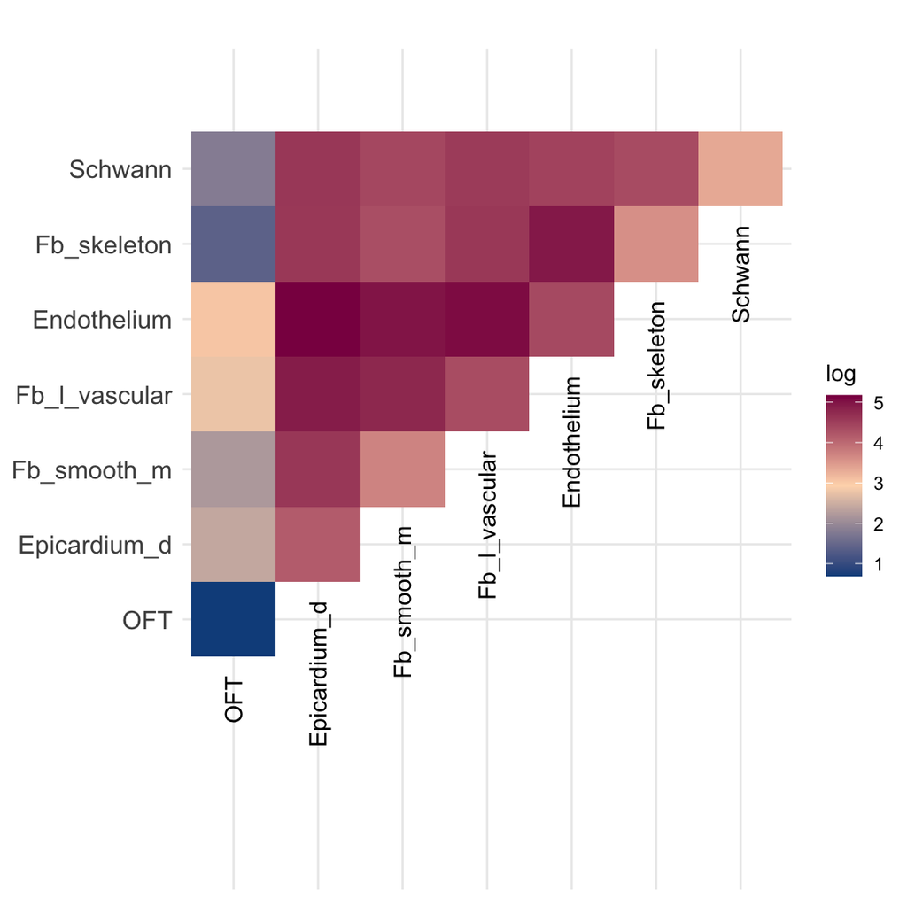

```r
# heatmap with desired order of clusters

# next run below to get SOURCE/TARGET order as in cc file
# cellphonedb plot heatmap_plot metadata_M7.txt
# or
# cellphonedb plot heatmap_plot metadata_M5_SAN.txt
#system('cellphonedb plot heatmap_plot metadata_M7.txt')

count_network <- read.table('/Users/ChristerSylven/out/count_network.txt', header = TRUE)


#OFT cc <- c('M7', '2', '7', '6',  '0', '3', '15')
count_wide <- setDT(count_network %>% arrange(factor(SOURCE, levels = c('M7', '2', '7', '6',  '0', '3', '15'))))
count_wide <- dcast(count_wide, factor(SOURCE, levels = unique(c('15','3', '0', '6', '7', '2', 'M7'))) ~ factor(TARGET, levels = unique(c('15','3', '0', '6', '7', '2', 'M7'))), value.var = 'count')
count_wide <- count_wide[,-1]
count_wide[lower.tri(-count_wide)] = NA


cc <- c('OFT', 'Epicardium_d',  'Fb_smooth_m', 'Fb_l_vascular', 'Endothelium', 'Fb_skeleton', 'Schwann')

colnames(count_wide) <-  rev(cc)
count_wide$celltype <- rev(cc)
count_wide2 <- count_wide

count_wide2 <- na.omit(melt(count_wide2, 'celltype', variable='cohort'))
count_wide2$cohort <- factor(count_wide2$cohort)
count_wide2$celltype <- factor(count_wide2$celltype)

#head(count_wide2)
count_wide2$log <- log(count_wide2$value+1)

ggplot(data = count_wide2) +
  aes(x = cohort, y = celltype) +
  ggtitle('') +
  theme_bw() +
  xlab('') +
  ylab('') +
  geom_tile(aes(fill = log), colour = "transparent") +
  scale_fill_gradientn(colours = c("dodgerblue4", 'peachpuff', 'deeppink4')) +
  scale_x_discrete(limits = cc,
                   labels = cc) +
  scale_y_discrete(limits = cc,
                   labels = cc) +
  theme(
        axis.text.x = element_blank(),
        axis.text.y=element_text(size=12),
        axis.ticks=element_blank(),
        axis.line=element_blank(),
        axis.title.x=element_blank(),
        axis.title.y=element_blank(),
        panel.border=element_blank()) +
annotate("text", x = (1:length(levels(count_wide2$cohort))), y = 1:length(levels(count_wide2$cohort))- 0.75, label = rev(levels(count_wide2$cohort)), size=4, hjust = 1, angle = 90) +
  coord_cartesian(ylim = c(8, -2), clip = "off")
```

In the same way, create a metadata file for atrial conduit, SAN and colocalized cell types and generate count_network and triangular heatmap.

```r
metadata <- read.table('metadata.txt')
colnames(metadata) <- metadata[1,]
metadata <- metadata[-1,]

cc <- c('M5','SAN', '0', '2', '6', '7', '12', '15')
metadata_M5_SAN <- metadata[metadata$cell_type %in% cc,]
metadata_M5_SAN [,2]  <- factor(metadata_M5_SAN [,2]) # delete cluster w zero cells
write.table(metadata_M5_SAN,
            file = 'metadata_M5_SAN.txt',
            quote = F,
            #col.names = T,
            row.names = F,
            sep = '\t')

table(metadata_M5_SAN[,2])
```

```
##
##   0  12  15   2   6   7  M5 SAN
## 652 111  44 475 160 148  51   8
```

### Figure 4B

```r
plot <- "cellphonedb plot heatmap_plot metadata_M5_SAN.txt"
plot_address <- paste0(address, plot)
plot_address
```

```
## [1] "/Users/ChristerSylven/Library/Python/3.8/bin/cellphonedb plot heatmap_plot metadata_M5_SAN.txt"
```

```r
system(plot_address)
```

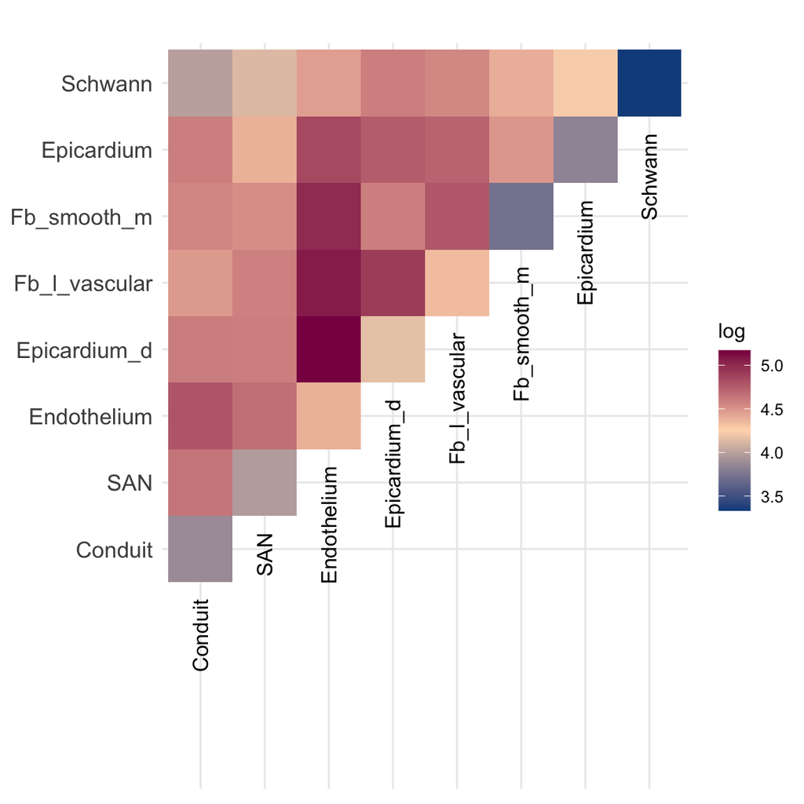

```r
#system('cellphonedb plot heatmap_plot metadata_M5_SAN.txt')
count_network <- read.table('/Users/ChristerSylven/out/count_network.txt', header = TRUE)
count_network[,1] <- as.factor(count_network[,1] )
count_network[,2] <- as.factor(count_network[,2])
count_network$log_count <- log(count_network$count +1 )
count_network$log_count2 <- count_network$log_count

#count_network

cc <-  c('M5','SAN', '6', '2', '3', '12', '4', '7')

# to construct a triangular heatmap of interactions do:
#Conduit + SAN
count_wide <- setDT(count_network %>% arrange(factor(SOURCE, levels = cc)))
count_wide <- dcast(count_wide, factor(SOURCE, levels = unique(c('15','12', '7', '6', '2', '0', 'SAN', 'M5'))) ~ factor(TARGET, levels = unique(c('15','12', '7', '6', '2', '0', 'SAN', 'M5'))), value.var = 'count')
count_wide <- count_wide[,-1]
count_wide[lower.tri(-count_wide)] = NA
#count_wide

cc <-  c('Conduit', 'SAN', 'Endothelium', 'Epicardium_d', 'Fb_l_vascular','Fb_smooth_m', 'Epicardium', 'Schwann')

colnames(count_wide) <- rev(cc)
count_wide$celltype <- rev(cc)
count_wide2 <- count_wide


#count_wide2

count_wide2 <- na.omit(melt(count_wide2, 'celltype', variable='cohort'))
count_wide2$cohort <- factor(count_wide2$cohort)
count_wide2$celltype <- factor(count_wide2$celltype)

#head(count_wide2)
count_wide2$log <- log(count_wide2$value+1)

ggplot(data = count_wide2) +
  aes(x = cohort, y = celltype) +
  ggtitle('') +
  theme_bw() +
  xlab('') +
  ylab('') +
  geom_tile(aes(fill = log), colour = "transparent") +
  scale_fill_gradientn(colours = c("dodgerblue4", 'peachpuff', 'deeppink4')) +
  scale_x_discrete(limits = cc,
                   labels = cc) +
  scale_y_discrete(limits = cc,
                   labels = cc) +
  theme(
    axis.text.x = element_blank(),
    axis.text.y=element_text(size=12),
    axis.ticks=element_blank(),
    axis.line=element_blank(),
    axis.title.x=element_blank(),
    axis.title.y=element_blank(),
    panel.border=element_blank()) +
  annotate("text", x = (1:length(levels(count_wide2$cohort))), y = 1:length(levels(count_wide2$cohort))- 0.75, label = rev(levels(count_wide2$cohort)), size=4, hjust = 1, angle = 90) +
  coord_cartesian(ylim = c(8, -2), clip = "off")
```

# Subgroup output

The basic /out/means.txt & /out/pvalues.text are first pruned by deletion of duplicates

Then the relation between integrin and non-integrin ligand_receptor pairs is plotted for interaction between different cardiomyocytes and cardiomyocytes and non-cardiomyocytes.

## Integrins / non integrins

### S Figure 4A

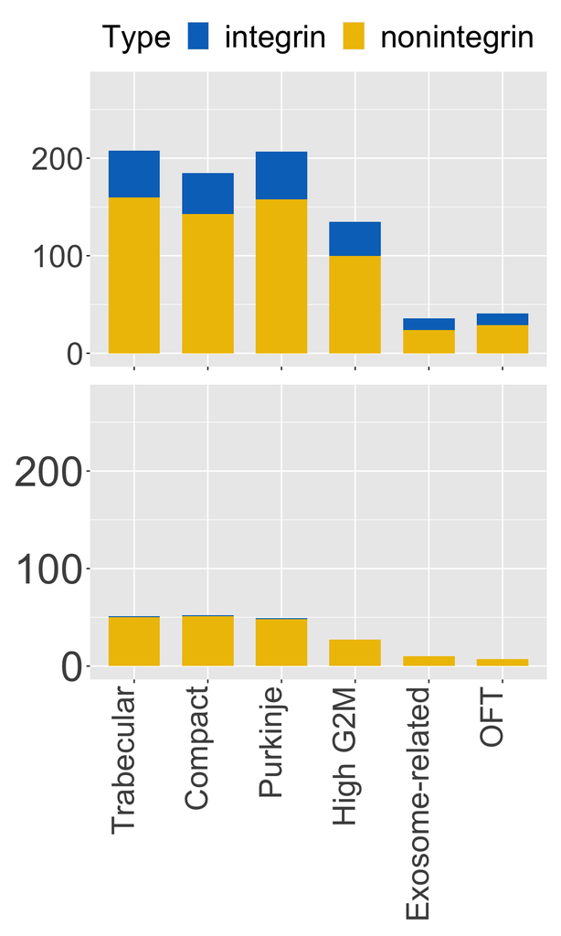

```r
#subgroup output
means <-  read.delim("/Users/ChristerSylven/out/means.txt", check.names = FALSE)
pvals <- read.delim("/Users/ChristerSylven/out/pvalues.txt", check.names = FALSE)
#pval[pval==0] = 0.0009
#dim(means)
#dim(pvals)

# delete duplicates of L_R / R_L interactoin pairs
pvals0 <- pvals[!duplicated(pvals[,1]),]
#pvals1 <- pvals[unique(pvals[,1]),]

means0 <- means[!duplicated(means[,1]),]
#dim(pvals0)
#dim(means0)
#add L_R / R_L interaction pairs as rowname
rownames(pvals0) <- pvals0[,2]
rownames(means0) <- means0[,2]
#pvals0[1:2,1:10]
#means0[1:2,1:10]
# make dataframe w L_R R_L interaction pairs, secreted, mol 1 rec, mol 2 rec, integrin
pvals_LR <- pvals0[,c(7:9,11)]
pvals_LR <- cbind(rownames(pvals_LR), pvals_LR)
colnames(pvals_LR)[1] <- 'L_R0'

# to find number of interactions and number of integrin interactions for each muscle subtype and subset pvals0 below and get table on number of integrins

is_integrin <- function(cell_interactions) {
  pvals2 <- pvals0[,cell_interactions]
  # keep L_R R_L interaction pair where any value in row has p value < 0.01
  pvals3 <- pvals2[apply(pvals2, 1, function(x) any(-log10(x) > 2)), ]
  t2<- sum(pvals_LR[rownames(pvals3),]$is_integrin == 'False')
  t3 <- sum(pvals_LR[rownames(pvals3),]$is_integrin == 'True')
  t1 <- t2 + t3
 # t[1,1] <- t1
  t[1,1] <- t2
  t[1,2] <- t3
  t <<- t # makes dataframe global
}

plot_interactions_integrins <- function(Number) {

  ordning <- c("Trabecular", "Compact", "Purkinje", "High G2M", "Exosome-related", 'OFT')
  muscle_muscle <- data.frame(
    Type = rep(c("nonintegrin", "integrin"), each = 6),
    Cell_type = rep((ordning), 2),
    Number = Number)

  ggplot(muscle_muscle, aes(x = Cell_type, y = Number)) +
    geom_col(aes(fill = Type), width = 0.7) +
    scale_fill_manual(values = c("#0073C2FF", "#EFC000FF")) +
    scale_x_discrete(limits = ordning, labels = ordning) +
    ylim(0, 275) +
    theme(
      axis.text.x = element_text(angle = 90, hjust = 1, vjust = 0, size = 32),
          axis.text.y = element_text(size = 32), legend.text =  element_text(size = 32),
          axis.title.x=element_blank(),
          axis.title.y=element_blank(),
      legend.title = element_text(size=24)
         # axis.text.x=element_blank(),
         # legend.position="none"
          )
}

#theme(axis.line=element_blank(),
     # axis.text.x=element_blank(),
      #axis.text.y=element_blank(),
      #axis.ticks=element_blank(),
      #axis.title.x=element_blank(),
      #axis.title.y=element_blank(),

Muscle_Muscle <- data.frame(
  M0 = c( 'M1|M0', 'M2|M0',  'M4|M0',  'M6|M0', 'M7|M0',  'M0|M1', 'M0|M2',  'M0|M4', 'M0|M6', 'M0|M7'),
M1 = c( 'M0|M1', 'M2|M1',  'M4|M1',  'M6|M1', 'M7|M1',  'M1|M0', 'M1|M2',  'M1|M4', 'M1|M6', 'M1|M7'),
M2  = c( 'M0|M2', 'M2|M2',  'M4|M2',  'M6|M2', 'M7|M2',  'M2|M0', 'M2|M1',  'M2|M4', 'M2|M6', 'M2|M7'),
M4 = c( 'M0|M4', 'M1|M4',  'M2|M4',  'M6|M4', 'M7|M4',  'M4|M0', 'M4|M1',  'M4|M2', 'M4|M6', 'M4|M7'),
M6 = c( 'M0|M6', 'M1|M6',  'M2|M6',  'M4|M6', 'M7|M6',  'M6|M0', 'M6|M1',  'M6|M2', 'M6|M4', 'M6|M7'),
M7 =c( 'M0|M7', 'M1|M7',  'M2|M7',  'M4|M7', 'M6|M7',  'M7|M0', 'M7|M1',  'M7|M2', 'M7|M4', 'M7|M6')
)

t <- data.frame()
T <- data.frame()
for (i in 1:6) {
  is_integrin( Muscle_Muscle[,i])
  T <- rbind(T, t)
}


colnames(T) <- c('non_integrins', 'integrins')
T$clusters <- c('M0', 'M1', 'M2', 'M4', 'M6', 'M7')
#T
T2 <- melt(as.data.table(T), id = 'clusters')
#plot_interactions_integrins(T2$value)

ordning <- c("Trabecular", "Compact", "Purkinje", "High G2M", "Exosome-related", 'OFT')
muscle_muscle <- data.frame(
  Type = rep(c("nonintegrin", "integrin"), each = 6),
  Cell_type = rep((ordning), 2),
  Number = T2$value)

p1 <- ggplot(muscle_muscle, aes(x = Cell_type, y = Number)) +
  geom_col(aes(fill = Type), width = 0.7) +
  scale_fill_manual(values = c("#0073C2FF", "#EFC000FF")) +
  scale_x_discrete(limits = ordning, labels = ordning) +
  ylim(0, 275) +
  theme(
    axis.text.x = element_text(angle = 90, hjust = 1, vjust = 0, size = 24),
    axis.text.y = element_text(size = 32), legend.text =  element_text(size = 24),
    axis.title.x=element_blank(),
    axis.title.y=element_blank(),
    legend.title = element_text(size=24),
    # axis.text.x=element_blank(),
    legend.position="none"
  )

# Total /Integrin to non CM
# M0 -> M7

Muscle <- data.frame(
  M0 = c('0|M0', '2|M0', '3|M0', '4|M0', '6|M0', '7|M0', '9|M0', '10|M0', '12|M0', '15|M0', '16|M0', 'M0|0', 'M0|2', 'M0|2', 'M0|4', 'M0|6', 'M0|7', 'M0|9', 'M0|10', 'M0|12', 'M0|15', 'M0|16'),
  M1 = c('0|M1', '2|M1', '3|M1', '4|M1', '6|M1', '7|M1', '9|M1', '10|M1', '12|M1', '15|M1', '16|M1', 'M1|0', 'M1|2', 'M1|2', 'M1|4', 'M1|6', 'M1|7', 'M1|9', 'M1|10', 'M1|12', 'M1|15', 'M1|16'),
  M2  = c('0|M2', '2|M2', '3|M2', '4|M2', '6|M2', '7|M2', '9|M2', '10|M2', '12|M2', '15|M2', '16|M2', 'M2|0', 'M2|2', 'M2|2', 'M2|4', 'M2|6', 'M2|7', 'M2|9', 'M2|10', 'M2|12', 'M2|15', 'M2|16'),
  M4 = c('0|M4', '2|M4', '3|M4', '4|M4', '6|M4', '7|M4', '9|M4', '10|M4', '12|M4', '15|M4', '16|M4', 'M4|0', 'M4|2', 'M4|2', 'M4|4', 'M4|6', 'M4|7', 'M4|9', 'M4|10', 'M4|12', 'M4|15', 'M4|16'),
  M6 = c('0|M6', '2|M6', '3|M6', '4|M6', '6|M6', '7|M6', '9|M6', '10|M6', '12|M6', '15|M6', '16|M6', 'M6|0', 'M6|2', 'M6|2', 'M6|4', 'M6|6', 'M6|7', 'M6|9', 'M6|10', 'M6|12', 'M6|15', 'M6|16'),
  M7 =c('0|M7', '2|M7', '3|M7', '4|M7', '6|M7', '7|M7', '9|M7', '10|M7', '12|M7', '15|M7', '16|M7', 'M7|0', 'M7|2', 'M7|2', 'M7|4', 'M7|6', 'M7|7', 'M7|9', 'M7|10', 'M7|12', 'M7|15', 'M7|16')
)

t <- data.frame()
T <- data.frame()
for (i in 1:6) {
  is_integrin( Muscle[,i])
  T <- rbind(T, t)
}
colnames(T) <- c('non-integrins', 'integrins')
T$clusters <- c('M0', 'M1', 'M2', 'M4', 'M6', 'M7')
#T
T2 <- melt(as.data.table(T), id = 'clusters')
#plot_interactions_integrins(T2$value)

muscle_muscle <- data.frame(
  Type = rep(c("nonintegrin", "integrin"), each = 6),
  Cell_type = rep((ordning), 2),
  Number = T2$value)

p2 <- ggplot(muscle_muscle, aes(x = Cell_type, y = Number)) +
  geom_col(aes(fill = Type), width = 0.7) +
  scale_fill_manual(values = c("#0073C2FF", "#EFC000FF")) +
  scale_x_discrete(limits = ordning, labels = ordning) +
  ylim(0, 275) +
  theme(
    #axis.text.x = element_text(angle = 90, hjust = 1, vjust = 0, size = 32),
    axis.text.x = element_blank(),
    axis.text.y = element_text(size = 24), legend.text =  element_text(size = 24),
    axis.title.x=element_blank(),
    axis.title.y=element_blank(),
    legend.title = element_text(size=24),
    # axis.text.x=element_blank(),
    legend.position="top"
  )

p2/p1
```

To find Ligand_receptor dotplot according to cellphone DB and then edit results for

1. selected top LR pairs
2. rearrange so that pairs are shown as L-R and not R_L and make dotplot.
1. Plot as out/cellphoneDB plot and decide which pairs are top pairs
2. If out/cellphoneDB only show limited interactions as for M6, M7 analysis and ordering can be made directly manually.

## OFT and its interactions

system(‘cellphonedb plot dot_plot –rows in/OFT_pvals2_Nov_rows.txt –columns in/OFT_Nov.txt –output-name OFT_Nov.png’)

OFT_Nov.png saved in out folder with only 27 interactions, no selection is needed

```r
#,2, 7, 6,  0, 3, 15
OFT <- c('2|M7', '7|M7', '6|M7', '0|M7', '3|M7', '15|M7', 'M7|2', 'M7|7', 'M7|6', 'M7|0', 'M7|3', 'M7|15')
write.table(OFT, file = '/Users/ChristerSylven/in/OFT_Nov.txt', sep = '\t', quote = F, row.names = F, col.names = F)

pvals2 <- pvals0[,OFT]
# to minimze number of interactions, filtered to those with p<0.01
pvals3 <- pvals2[apply(pvals2, 1, function(x) any(-log10(x) > 2)), ]
means3 <- means0[rownames(pvals3),OFT]
dim(pvals3) # 27 12
```

```
## [1] 27 12
```

```r
write.table(rownames(pvals3), '/Users/ChristerSylven/in/OFT_pvals2_Nov_rows.txt', sep = '\t', quote = F, row.names = F, col.names = F)
OFT <- c('2|M7', '7|M7', '6|M7', '0|M7', '3|M7', '15|M7', 'M7|2', 'M7|7', 'M7|6', 'M7|0', 'M7|3', 'M7|15')


pvals4_calc <- function(name, LRmrna, LRcells )
{
  pvals2 <- pvals0[,LRcells] #pval0 duplicates eliminated above
  pvals3 <- pvals2[apply(pvals2, 1, function(x) any(-log10(x) > 2)), ]
  pvals3 <- pvals3[LRmrna,]
  means3 <- means0[rownames(pvals3), LRcells]
  pvals_LR_rows <- pvals_LR[rownames(pvals3),]
  pvals4 <- cbind(pvals3,pvals_LR_rows)
  means4 <- cbind(means3,pvals_LR_rows)
  writexl::write_xlsx(pvals4, paste0("pvals4_d_", name, ".xlsx"))
 writexl::write_xlsx(means4, paste0("means4_d_", name, ".xlsx"))
}

pvals4_calc('OFT_TOP', rownames(pvals3), OFT)
```

Edit in excel. Change RL to LR into L_R column. Change values accordingly.

For those changed correct mean molecule1/molecule2 in excel to molecule2/molecule1 (1/value)

Save as b for both corrected pvals and means files with all pairs as L_R.

### Figure 3D

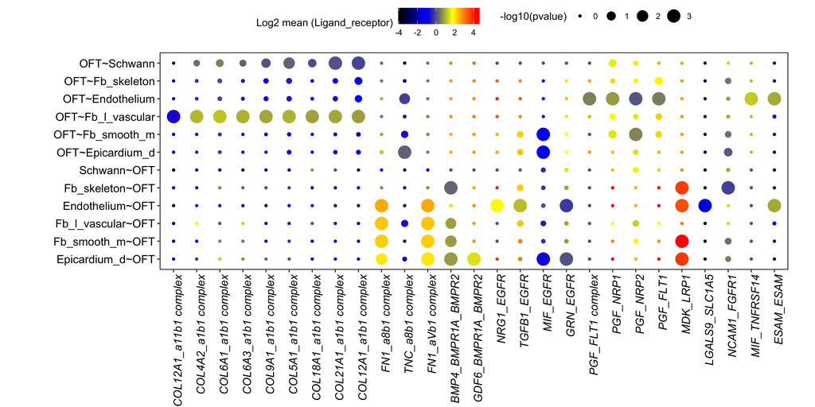

```r
pvals4b <- read_xlsx('/Users/ChristerSylven/pvals4_d_OFT_TOPb.xlsx')
means4b <- read_xlsx('/Users/ChristerSylven/means4_d_OFT_TOPb.xlsx')
# edit which pairs and order
#namn_OFT <- c(8:10,12,13:23,27, 24:25,28:30)

# function for manual dotplot, order and edited L_R pairs given by namn, default all LR pairs in 4b files
dotplot_LR <- function(pvals4b, means4b, L_Rs, namn = c(1:dim(pvals4b)[1]))
{
pvals4b <- as.data.frame(pvals4b)
means4b <- as.data.frame(means4b)
rownames(pvals4b) <- pvals4b[,18]
pvals4b <- pvals4b[,c(18, 1:12)]
pvals4b[pvals4b==0] = 0.0009

means4b <- means4b[,c(18, 1:12)]
means4b[means4b==0] = 1
pvals4b <- pvals4b[namn,]
means4b <- means4b[namn,]

pvals5 <- reshape2::melt(pvals4b, id=c('L_R'))
means5 <- reshape2::melt(means4b, id = c('L_R'))

level1 <- pvals5[1:dim(pvals4b)[1],1]
plot.data = cbind(pvals5,log2(means5[,3]))

colnames(plot.data) = c('pair', 'clusters', 'pvalue', 'mean')

my_palette <- colorRampPalette(c("black", "blue", "yellow", "red"), alpha=TRUE)(n=399)
#my_palette <- colorRampPalette(c("blue", "red"), alpha=TRUE)(n=399)

p <- ggplot2::ggplot(plot.data,aes(x=clusters,y=pair)) +
  geom_point(aes(size=-log10(pvalue),color=mean)) +
  scale_color_gradientn('Log2 mean (Ligand_receptor)', colors=my_palette) +
  scale_y_discrete(limits = level1,
                   labels = level1)+
  theme_bw() +
  theme(panel.grid.minor = element_blank(),
        panel.grid.major = element_blank(),
        axis.text=element_text(size=12, colour = "black"),
        axis.text.x = element_text(angle = 90, face = 'italic', hjust = 1, vjust=1),
        axis.text.y = element_text(size=12,  colour = "black"),
        axis.title=element_blank(),
        panel.border = element_rect(size = 0.7, linetype = "solid", colour = "black"),
        legend.position="top",
        plot.margin = unit(c(0.1,1,0,2), "cm")) +
        scale_x_discrete(
          labels = L_Rs) +
coord_flip()

ggsave("/Users/ChristerSylven/Desktop/CMC_ms/GitHub_code/non_Cond_SAN_CM_L_R.pdf", p, height = 10, width = 12,  device = "pdf")

p
}

L_Rs_OFT <- c("Epicardium_d~OFT",
"Fb_smooth_m~OFT",
"Fb_l_vascular~OFT",
"Endothelium~OFT",
"Fb_skeleton~OFT",
"Schwann~OFT",
"OFT~Epicardium_d",
"OFT~Fb_smooth_m",
"OFT~Fb_l_vascular",
"OFT~Endothelium",
"OFT~Fb_skeleton",
"OFT~Schwann")

dotplot_LR(pvals4b, means4b, L_Rs_OFT)
```

## Exosome-enriched interactions

```r
EXO <- c('2|M6', '7|M6', '6|M6', '0|M6', '3|M6', '15|M6', 'M6|2', 'M6|7', 'M6|6', 'M6|0', 'M6|3', 'M6|15')
write.table(EXO, file  = '/Users/ChristerSylven/in/EXO_Nov.txt', sep = '\t', quote = F, row.names = F, col.names = F)
pvals2 <- pvals0[,EXO]
# to minimze number of interactions, filtered to those with p<0.01
pvals3 <- pvals2[apply(pvals2, 1, function(x) any(-log10(x) > 2)), ]
means3 <- means0[rownames(pvals3),EXO]
dim(pvals3) # 31 12
```

```
## [1] 32 12
```

```r
write.table(rownames(pvals3), '/Users/ChristerSylven/in/EXO_pvals2_Nov_rows.txt', sep = '\t', quote = F, row.names = F, col.names = F)


pvals4_calc('EXO_TOP', rownames(pvals3), EXO)
```

system(‘cellphonedb plot dot_plot –rows in/EXO_pvals2_Nov_rows.txt –columns in/EXO_Nov.txt –output-name EXO_Nov.png’)

### S Figure 4B

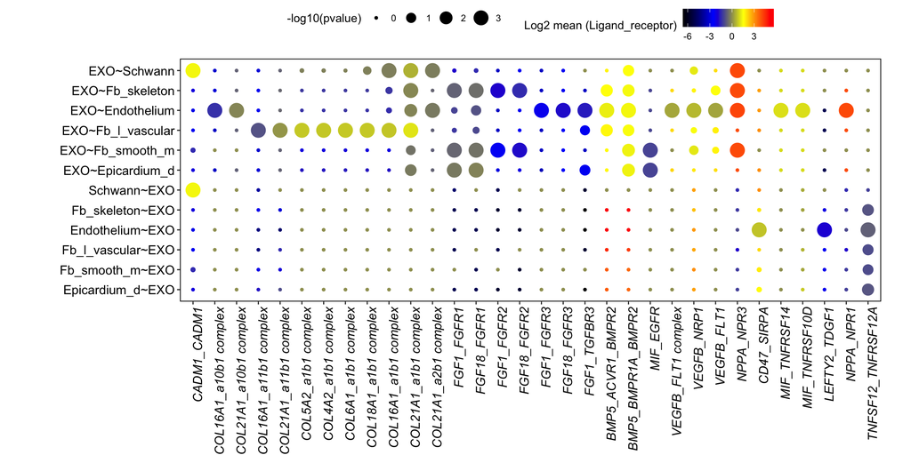

```r
# edit in excel. Change RL to LR into L_R column. Change values accordingly. Save as b for both files.
# Correct mean molecule1/molecule2 in excel with  to molecule2/molecule1 (1/value)
#
#corrected files with all pairs as L_R saved as c
pvals4b <- read_xlsx('/Users/ChristerSylven/pvals4_d_EXO_TOPb.xlsx')
means4b <- read_xlsx('/Users/ChristerSylven/means4_d_EXO_TOPb.xlsx')

L_Rs_EXO <- c("Epicardium_d~EXO",
"Fb_smooth_m~EXO",
"Fb_l_vascular~EXO",
"Endothelium~EXO",
"Fb_skeleton~EXO",
"Schwann~EXO",
"EXO~Epicardium_d",
"EXO~Fb_smooth_m",
"EXO~Fb_l_vascular",
"EXO~Endothelium",
"EXO~Fb_skeleton",
"EXO~Schwann")
#Edited L_R order:
namn_exo <- c(2:19,23:25,22, 28:29,20:21,27,30,32:33,26,31)
dotplot_LR(pvals4b, means4b, L_Rs_EXO)
```

## Atrial conduit & SAN interactions

plotted as two plots: non-CM to CM cells and CM to non-CM cells.

non-CM to CM number of ligand_receptor pairs

```r
ALL_Cond_SAN <- c('0|M5', '2|M5', '6|M5', '7|M5', '12|M5',  '15|M5',  '0|SAN', '2|SAN', '6|SAN', '7|SAN', '12|SAN', '15|SAN')
Cond_SAN_ALL <- c('M5|0', 'M5|2', 'M5|6', 'M5|7', 'M5|12', 'M5|15','SAN|0', 'SAN|2', 'SAN|6', 'SAN|7', 'SAN|12', 'SAN|15')
write.table(ALL_Cond_SAN, file = '/Users/ChristerSylven/in/ALL_Cond_SAN_Nov.txt', sep = '\t', quote = F, row.names = F, col.names = F)
write.table(Cond_SAN_ALL, file  = '/Users/ChristerSylven/in/Cond_SAN_ALL_Nov.txt', sep = '\t', quote = F, row.names = F, col.names = F)

pvals2 <- pvals0[,Cond_SAN_ALL]
# to minimze number of interactions, filtered to those with p<0.01
pvals3 <- pvals2[apply(pvals2, 1, function(x) any(-log10(x) > 2)), ]
means3 <- means0[rownames(pvals3),Cond_SAN_ALL]

nrow(pvals3)
```

```
## [1] 136
```

```r
write.table(rownames(pvals3), '/Users/ChristerSylven/in/Cond_SAN_ALL_pvals2_Nov_rows.txt', sep = '\t', quote = F, row.names = F, col.names = F)
```

system(‘cellphonedb plot dot_plot –rows in/Cond_SAN_ALL_pvals2_Nov_rows.txt –columns in/Cond_SAN_ALL_Nov.txt –output-name Cond_SAN_ALL_Nov.png’)

CM to non-CM number of ligand_receptor pairs

```r
pvals2 <- pvals0[,ALL_Cond_SAN]
# to minimze number of interactions, filtered to those with p<0.01
pvals3 <- pvals2[apply(pvals2, 1, function(x) any(-log10(x) > 2)), ]
means3 <- means0[rownames(pvals3),ALL_Cond_SAN]

nrow(pvals3)
```

```
## [1] 156
```

```r
write.table(rownames(pvals3), '/Users/ChristerSylven/in/ALL_Cond_SAN_pvals2_Nov_rows.txt', sep = '\t', quote = F, row.names = F, col.names = F)
```

Too many ligand_receptor pairs. Selection of top pairs

In order to edit so that all pairs are annotated as L_R and not R_L produce xlsx files as below and edit. R_L becomes L_R in the CONDUIT_SAN_TOP and vice versa. For means the ratio has to be changed by 1/value. Edited xlsx files are saved with suffix b and then opened to make the ggplot manually.

system(‘cellphonedb plot dot_plot –rows in/COND_SAN_ALL_TOP_May_rows.txt –columns in/Cond_SAN_all_May.txt –output-name Cond_SAN_TOP_all_May.png’)

### Figure 4C

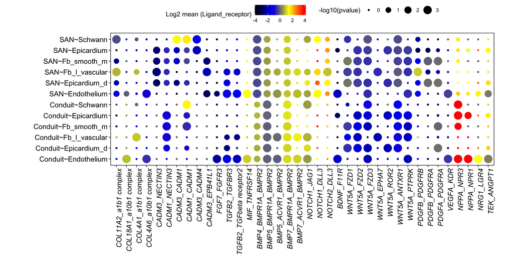

```r
COND_SAN_ALL_TOP <- c(
  'COL11A2_a1b1 complex',
  'COL18A1_a10b1 complex',
  'COL4A1_a1b1 complex',
  'COL4A6_a10b1 complex',
  'CADM3_NECTIN3',
  'CADM1_NECTIN3',
  'CADM3_CADM1',
  'CADM1_CADM1',
  'CADM3_CADM4',
  'CADM3_EPB41L1',
  'FGF7_FGFR3',
  'TGFB2_TGFBR3',
  'TGFB2_TGFbeta receptor2',
  'MIF_TNFRSF14',
  'BMR1A_AVR2B_GDF6',
  'BMPR1A_BMPR2_GDF6',
  'BMR1A_AVR2B_BMP4',
  'BMPR1A_BMPR2_BMP4',
  'ADGRL1_NRG1',
  'EGFR_TGFB1',
  'EGFR_MIF',
  'EGFR_GRN',
  'BDNF_F11R',
  'WNT5A_FZD1',
  'WNT5A_FZD2',
  'WNT5A_FZD3',
  'WNT5A_EPHA7',
  'WNT5A_ROR2',
  'WNT5A_ANTXR1',
  'WNT5A_PTPRK',
  'GDF11_ANTXR1',
  'PDGFB_PDGFRB',
  'PDGFB_PDGFRA',
  'PDGFA_PDGFRA',
  'VEGFA_KDR',
  'NPPA_NPR3',
  'NPPA_NPR1'
  )

write.table(COND_SAN_ALL_TOP, '/Users/ChristerSylven/in/COND_SAN_ALL_TOP_May_rows.txt', sep = '\t', quote = F, row.names = F, col.names = F)

pvals4_calc('COND_SAN_ALL_TOP', COND_SAN_ALL_TOP, Cond_SAN_ALL)

L_Rs_COND_SAN_nonCM <- c(
"Conduit~Endothelium",
"Conduit~Epicardium_d",
"Conduit~Fb_l_vascular",
"Conduit~Fb_smooth_m",
"Conduit~Epicardium",
"Conduit~Schwann",
"SAN~Endothelium",
"SAN~Epicardium_d",
"SAN~Fb_l_vascular",
"SAN~Fb_smooth_m",
"SAN~Epicardium",
"SAN~Schwann"
)

# edit in excel and save as _c
pvals4b <- read_xlsx('/Users/ChristerSylven/pvals4_d_COND_SAN_ALL_TOPb.xlsx')
means4b <- read_xlsx('/Users/ChristerSylven/means4_d_COND_SAN_ALL_TOPb.xlsx')
dotplot_LR(pvals4b, means4b,L_Rs_COND_SAN_nonCM)
```

system(‘cellphonedb plot dot_plot –rows in/ALL_CONDUIT_SAN_TOP_Oct_rows.txt –columns in/ALL_Cond_SAN_Oct.txt –output-name ALL_Cond_SAN_TOP_Oct.png’)

### Figure 4D

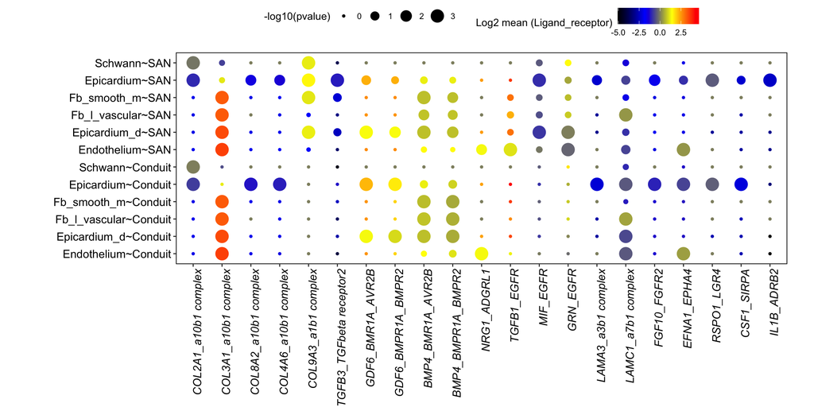

```r
# from the output choice of those to display in figure

ALL_CONDUIT_SAN_TOP <-
c(
  'COL2A1_a10b1 complex',
  'COL3A1_a10b1 complex',
  'COL8A2_a10b1 complex',
  'COL4A6_a10b1 complex',
  'COL9A3_a1b1 complex',
  'TGFB3_TGFbeta receptor2',
  'BMPR1A_BMPR2_BMP4',
  'BMPR1A_BMPR2_BMP5',
  'ACVR1_BMPR2_BMP5',
  'BMPR1A_BMPR2_BMP7',
  'ACVR1_BMPR2_BMP7',
  'NOTCH1_JAG1',
  'NOTCH1_DLL3',
  'NOTCH2_DLL3',
  'LAMA3_a3b1 complex',
  'LAMC1_a7b1 complex',
  'FGF10_FGFR2',
  'EFNA1_EPHA4',
  'RSPO1_LGR4',
  'CSF1_SIRPA',
  'NRG1_LGR4',
  'IL1B_ADRB2',
  'TEK_ANGPT1'
)

write.table(ALL_CONDUIT_SAN_TOP, '/Users/ChristerSylven/in/ALL_CONDUIT_SAN_TOP_OCT_rows.txt', sep = '\t', quote = F, row.names = F, col.names = F)

pvals4_calc('ALL_Cond_SAN_TOP', ALL_CONDUIT_SAN_TOP, ALL_Cond_SAN)

pvals4b <- read_xlsx('/Users/ChristerSylven/pvals4_d_ALL_COND_SAN_TOPb.xlsx')
means4b <- read_xlsx('/Users/ChristerSylven/means4_d_ALL_COND_SAN_TOPb.xlsx')

L_Rs_nonCM_COND_SAN <- c(
"Endothelium~Conduit",
"Epicardium_d~Conduit",
"Fb_l_vascular~Conduit",
"Fb_smooth_m~Conduit",
"Epicardium~Conduit",
"Schwann~Conduit",
"Endothelium~SAN",
"Epicardium_d~SAN",
"Fb_l_vascular~SAN",
"Fb_smooth_m~SAN",
"Epicardium~SAN",
"Schwann~SAN"
)

dotplot_LR(pvals4b, means4b, L_Rs_nonCM_COND_SAN)
```